# 25_size_small_m-ary_tree

## 25_size_small_m-ary_tree

#### Question

1. In the forest diagram below, there are 6 [complete m-ary](https://en.wikipedia.org/wiki/M-ary_tree) trees. Each tree has a [branching factor](https://en.wikipedia.org/wiki/Branching_factor) of 2 and a maximum depth of 3 (so there are 4 different levels).

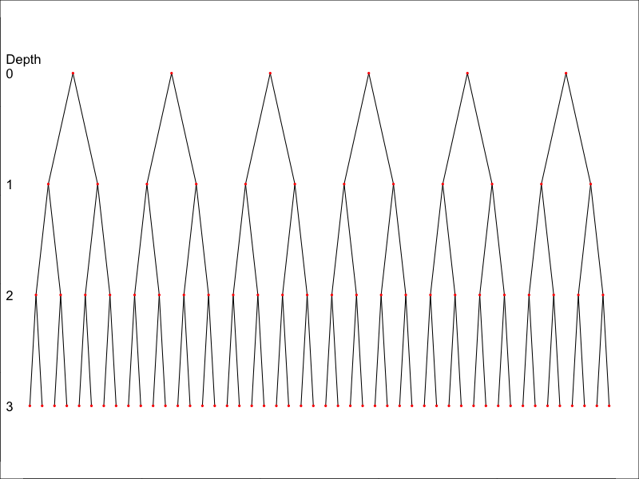

   How many nodes (red dots) are in the forest diagram? In other words, what is the size of the forest?

#### Question

2. In the forest diagram below, there are 5 [complete m-ary](https://en.wikipedia.org/wiki/M-ary_tree) trees. Each tree has a [branching factor](https://en.wikipedia.org/wiki/Branching_factor) of 6 and a maximum depth of 2 (so there are 3 different levels).

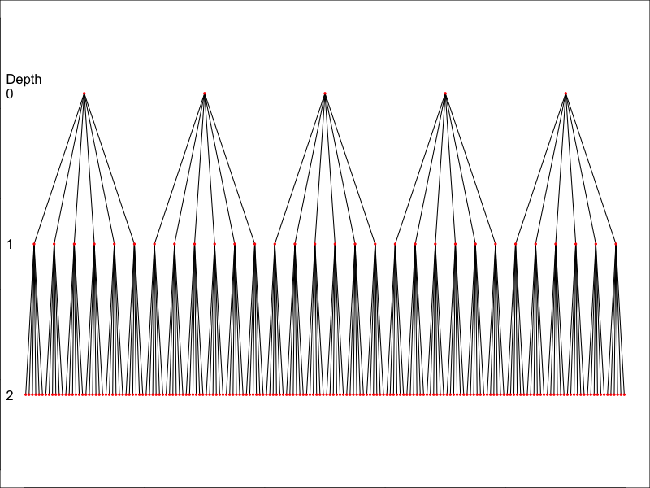

   How many nodes (red dots) are in the forest diagram? In other words, what is the size of the forest?

#### Question

3. In the forest diagram below, there are 3 [complete m-ary](https://en.wikipedia.org/wiki/M-ary_tree) trees. Each tree has a [branching factor](https://en.wikipedia.org/wiki/Branching_factor) of 6 and a maximum depth of 2 (so there are 3 different levels).

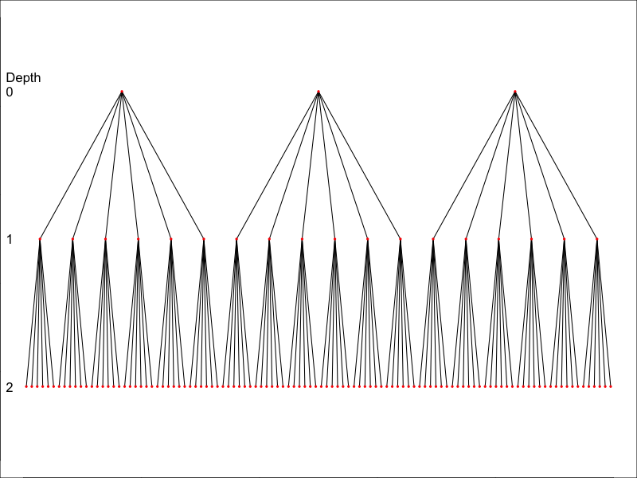

   How many nodes (red dots) are in the forest diagram? In other words, what is the size of the forest?

#### Question

4. In the forest diagram below, there are 7 [complete m-ary](https://en.wikipedia.org/wiki/M-ary_tree) trees. Each tree has a [branching factor](https://en.wikipedia.org/wiki/Branching_factor) of 3 and a maximum depth of 3 (so there are 4 different levels).

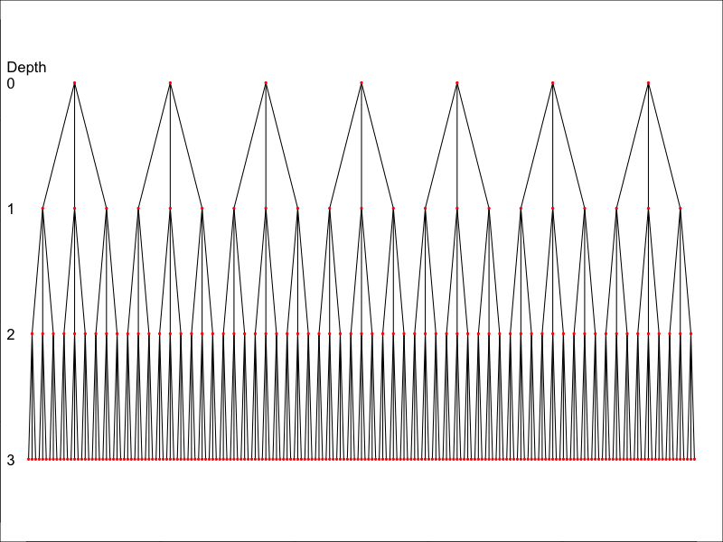

   How many nodes (red dots) are in the forest diagram? In other words, what is the size of the forest?

#### Question

5. In the forest diagram below, there are 6 [complete m-ary](https://en.wikipedia.org/wiki/M-ary_tree) trees. Each tree has a [branching factor](https://en.wikipedia.org/wiki/Branching_factor) of 3 and a maximum depth of 3 (so there are 4 different levels).

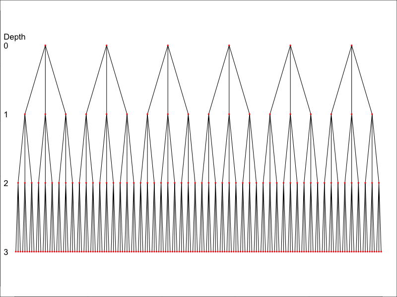

   How many nodes (red dots) are in the forest diagram? In other words, what is the size of the forest?

#### Question

6. In the forest diagram below, there are 7 [complete m-ary](https://en.wikipedia.org/wiki/M-ary_tree) trees. Each tree has a [branching factor](https://en.wikipedia.org/wiki/Branching_factor) of 4 and a maximum depth of 2 (so there are 3 different levels).

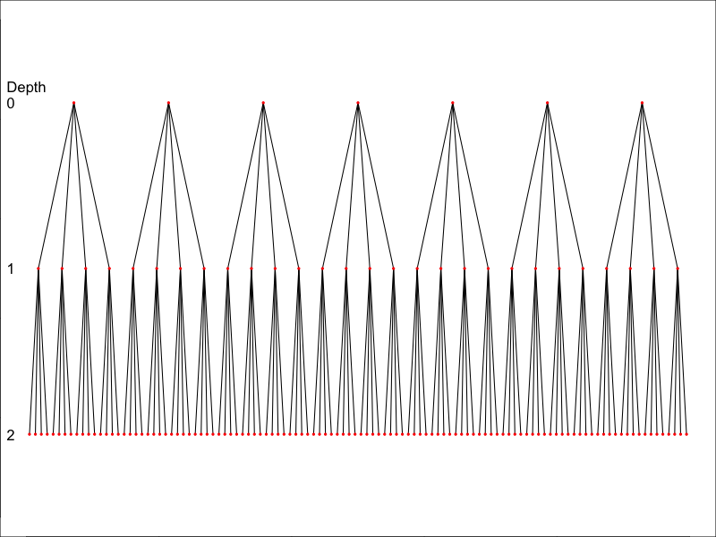

   How many nodes (red dots) are in the forest diagram? In other words, what is the size of the forest?

#### Question

7. In the forest diagram below, there are 4 [complete m-ary](https://en.wikipedia.org/wiki/M-ary_tree) trees. Each tree has a [branching factor](https://en.wikipedia.org/wiki/Branching_factor) of 3 and a maximum depth of 2 (so there are 3 different levels).

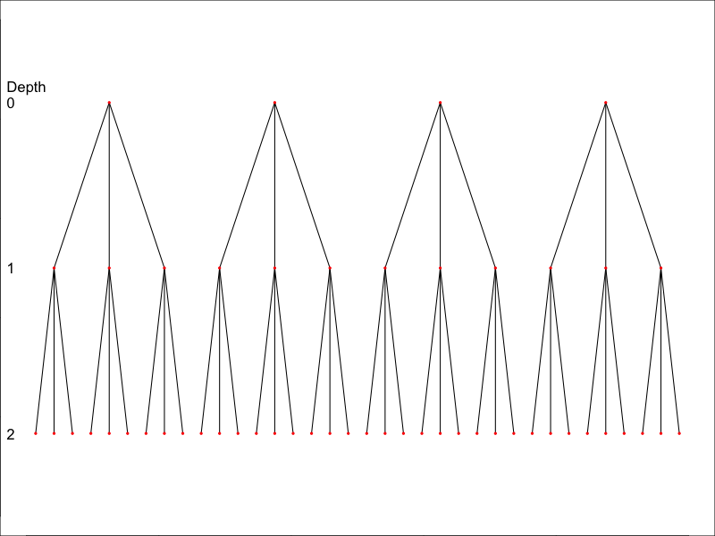

   How many nodes (red dots) are in the forest diagram? In other words, what is the size of the forest?

#### Question

8. In the forest diagram below, there are 3 [complete m-ary](https://en.wikipedia.org/wiki/M-ary_tree) trees. Each tree has a [branching factor](https://en.wikipedia.org/wiki/Branching_factor) of 5 and a maximum depth of 2 (so there are 3 different levels).

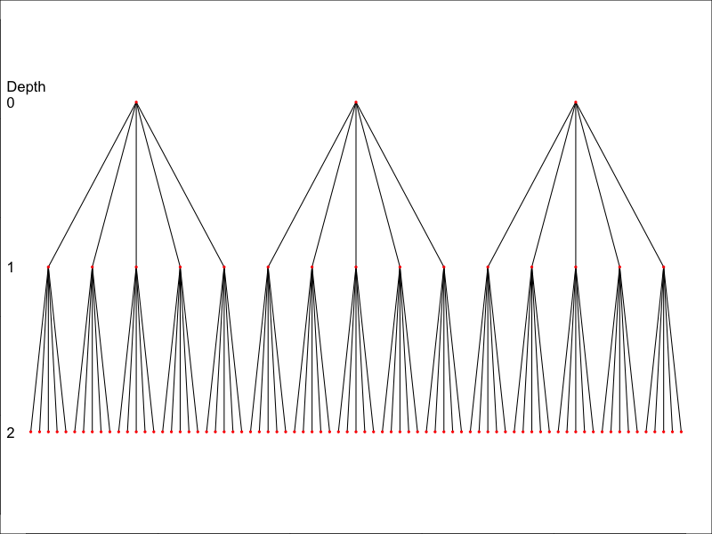

   How many nodes (red dots) are in the forest diagram? In other words, what is the size of the forest?